# Lab07

Yixuan Li, UPI:yil845

26 September 2021

### The Data: The data is from UCI Machine Learning Repository about the Automobile data set.

## Modelling Nonlinear Relationship

### Consider polynomial regression models using highway.mpg to predict the value of price.

```r
polyn1<- lm(price ~ poly(highway.mpg,1,raw = TRUE),data=auto)
polyn2<-lm(price ~ poly(highway.mpg,2,raw = TRUE),data=auto)
polyn3<-lm(price ~ poly(highway.mpg,3,raw = TRUE),data=auto)
polyn4<-lm(price ~ poly(highway.mpg,4,raw = TRUE),data=auto)
polyn5<-lm(price ~ poly(highway.mpg,5,raw = TRUE),data=auto)
summary(polyn3)
```

```
##
## Call:
## lm(formula = price ~ poly(highway.mpg, 3, raw = TRUE), data = auto)
##
## Residuals:
##     Min      1Q  Median      3Q     Max
## -8451.8 -1629.1  -354.6   938.1 14416.3
##
## Coefficients:
##                                     Estimate Std. Error t value Pr(>|t|)
## (Intercept)                       93247.4598 18002.8700   5.180 6.82e-07 ***
## poly(highway.mpg, 3, raw = TRUE)1 -5070.7914  1612.7900  -3.144   0.0020 **
## poly(highway.mpg, 3, raw = TRUE)2    95.5198    46.6719   2.047   0.0424 *
## poly(highway.mpg, 3, raw = TRUE)3    -0.5756     0.4357  -1.321   0.1884
## ---
## Signif. codes:  0 '***' 0.001 '**' 0.01 '*' 0.05 '.' 0.1 ' ' 1
##
## Residual standard error: 3446 on 155 degrees of freedom
## Multiple R-squared:  0.6629, Adjusted R-squared:  0.6564
## F-statistic: 101.6 on 3 and 155 DF,  p-value: < 2.2e-16
```

### 2, Superimpose them all in one scatter plot of the data. What do you generally observe in the fitted curve when the polynomial degree increases?

### Visually speaking, the 2nd and the 3rd degree polynomial fitting are the best. Increasing degree could only cause over-intepretation of results because of the high noise level and very bumpy curves.

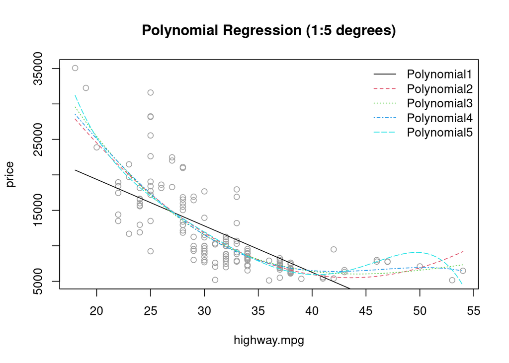

```r
### generate a random seq as sample data and fit them with polynormial coefficient 1:10
newx<- data.frame(highway.mpg = seq(min(auto$highway.mpg),max(auto$highway.mpg),by=0.1))
with(auto,plot(highway.mpg,price,pch=21,col=8, main="Polynomial Regression (1:5 degrees)"))
for (i in 1:5) {
  r.poly = lm(price ~ poly(highway.mpg,i,raw = TRUE),data=auto)
  yhat.poly = predict(r.poly, newx)
  lines(newx$highway.mpg,yhat.poly,lty = i, col = i)
}
legend("topright",lty=1:5, col = 1:5,paste0("Polynomial",1:5),bty = "n")
```

### 3, Find the BIC-selected polynomial regression model. Do you think this is a reasonable fit?

## The result seems reasonable. The second BIC (degree of 2) is the smallest, thus the best fitting. But it only based on the log-likelihood fitting of 159 observations and k parameters in the dataset. Noted this calculated BIC is a relative value because the constant C is not included. According to in-build BIC() function, the constant is -344.5955.

```r
n<-nrow(auto)
BIC1<- log(sum(residuals(polyn1)^2))*n+log(n)*(length(polyn1$coefficients)-1)
BIC2<- log(sum(residuals(polyn2)^2))*n+log(n)*(length(polyn2$coefficients)-1)
BIC3<- log(sum(residuals(polyn3)^2))*n+log(n)*(length(polyn3$coefficients)-1)
BIC4<- log(sum(residuals(polyn4)^2))*n+log(n)*(length(polyn4$coefficients)-1)
BIC5<- log(sum(residuals(polyn5)^2))*n+log(n)*(length(polyn5$coefficients)-1)
BIC1;BIC2;BIC3;BIC4;BIC5
```

```
## [1] 3453.712
```

```
## [1] 3403.894
```

```
## [1] 3407.183
```

```
## [1] 3411.729
```

```
## [1] 3412.667
```

```r
min(BIC1,BIC2,BIC3,BIC4,BIC5)
```

```
## [1] 3403.894
```

```r
## Comparison to results from in-build BIC()
BIC(polyn1); BIC(polyn2);BIC(polyn3);BIC(polyn4); BIC(polyn5)
```

```
## [1] 3109.116
```

```
## [1] 3059.298
```

```
## [1] 3062.587
```

```
## [1] 3067.134
```

```
## [1] 3068.072
```

```r
## Constant
BIC(polyn1)-BIC1; BIC(polyn5)-BIC5
```

```
## [1] -344.5955
```

```
## [1] -344.5955
```

## Generalised Additive Models

### 4, Fit a GAM to the data set, using a smoothing spline with 5 degrees of freedom for each predictor variable: wheel.base, length, height, highway.mpg.

```r
r.gam = gam(price ~ s(wheel.base, 5) + s(length,5) + s(height, 5) + s(highway.mpg,5), data=auto)
summary((r.gam))
```

```
##
## Call: gam(formula = price ~ s(wheel.base, 5) + s(length, 5) + s(height,
##     5) + s(highway.mpg, 5), data = auto)
## Deviance Residuals:
##     Min      1Q  Median      3Q     Max
## -7655.4 -1132.0  -111.5   726.5 10546.1
##
## (Dispersion Parameter for gaussian family taken to be 6419159)
##
##     Null Deviance: 5458772565 on 158 degrees of freedom
## Residual Deviance: 885845691 on 138.0003 degrees of freedom
## AIC: 2964.993
##
## Number of Local Scoring Iterations: NA
##
## Anova for Parametric Effects
##                    Df     Sum Sq    Mean Sq F value    Pr(>F)
## s(wheel.base, 5)    1 2796569269 2796569269 435.660 < 2.2e-16 ***
## s(length, 5)        1  483447711  483447711  75.313 1.003e-14 ***
## s(height, 5)        1  125420980  125420980  19.538 1.980e-05 ***
## s(highway.mpg, 5)   1  361611027  361611027  56.333 6.835e-12 ***
## Residuals         138  885845691    6419159
## ---
## Signif. codes:  0 '***' 0.001 '**' 0.01 '*' 0.05 '.' 0.1 ' ' 1
##
## Anova for Nonparametric Effects
##                   Npar Df  Npar F     Pr(F)
## (Intercept)
## s(wheel.base, 5)        4  6.7856 5.137e-05 ***
## s(length, 5)            4  0.9532   0.43542
## s(height, 5)            4  2.2284   0.06906 .
## s(highway.mpg, 5)       4 15.2155 2.491e-10 ***
## ---
## Signif. codes:  0 '***' 0.001 '**' 0.01 '*' 0.05 '.' 0.1 ' ' 1
```

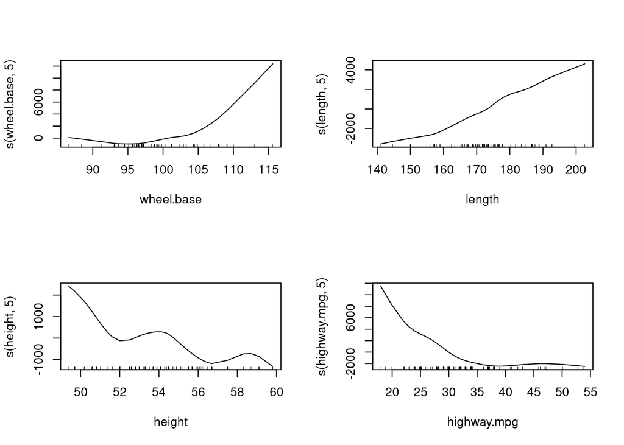

```r
par(mfrow=c(2,2))
plot(r.gam)
```

### 5, Use GAM to predict the price value for a new observation: wheel.base = 110, length = 190, height = 55, highway.mpg = 25.

```r
new<- data.frame(wheel.base = 110,length = 190, height = 55, highway.mpg = 25)
predict(r.gam,new)
```

```
##        1
## 22908.86
```

### 6, Re-fit GAM by adjusting manually the degrees of freedom of smoothing splines. Here I manually adjusted gam smooth spline from degree 2-5. Visually speaking, the good fit is between 2-3 degrees of freedom for all variables.

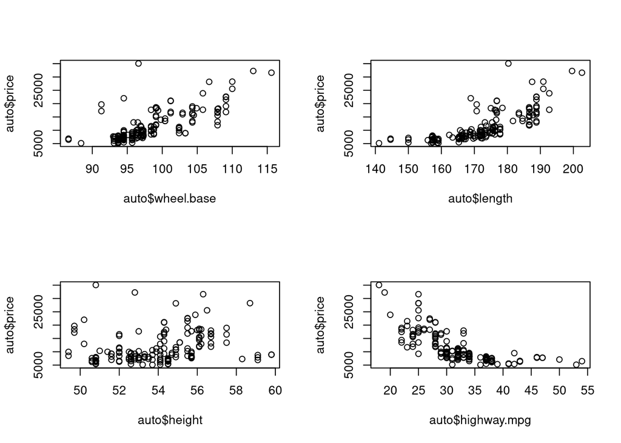

```r
r.gam2 = gam(price ~ s(wheel.base, 2) + s(length,2) + s(height, 2) + s(highway.mpg,2), data=auto)
r.gam3 = gam(price ~ s(wheel.base, 3) + s(length,3) + s(height, 3) + s(highway.mpg,3), data=auto)
r.gam4 = gam(price ~ s(wheel.base, 4) + s(length,4) + s(height, 4) + s(highway.mpg,4), data=auto)
r.gam5 = gam(price ~ s(wheel.base, 5) + s(length,5) + s(height, 5) + s(highway.mpg,5), data=auto)

par(mfrow=c(2,2))
plot(auto$wheel.base,auto$price); plot(auto$length,auto$price);plot(auto$height,auto$price);plot(auto$highway.mpg,auto$price)
```

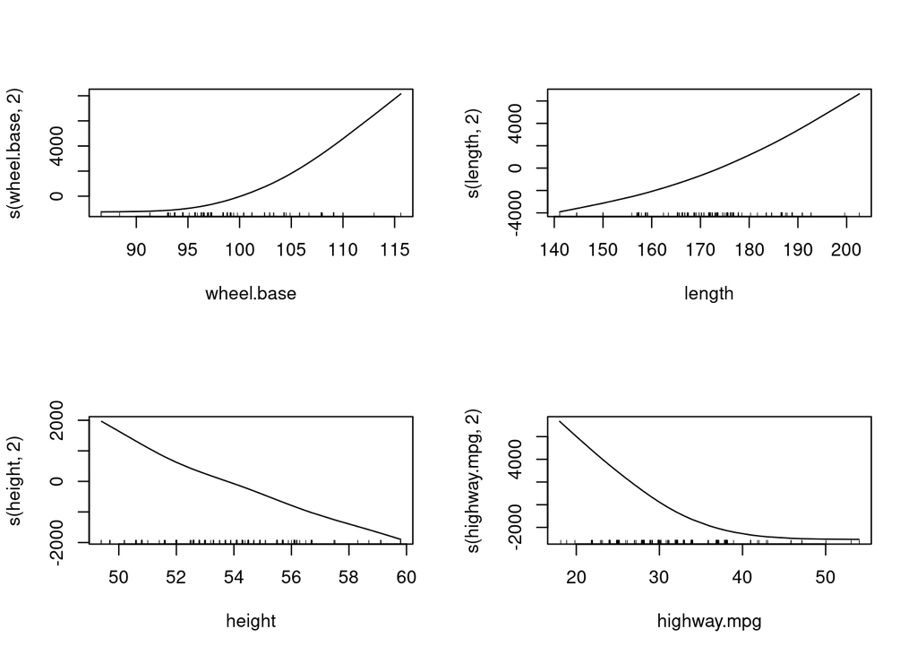

```r
plot(r.gam2)
```

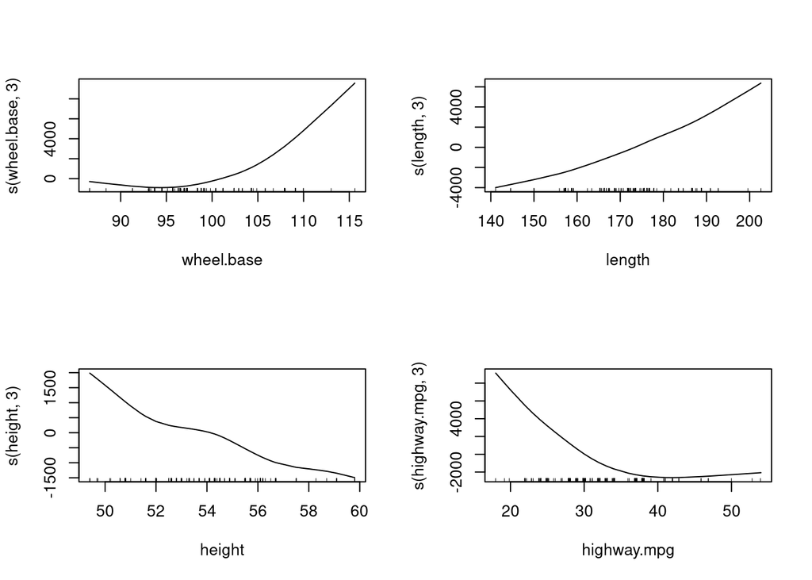

```r
plot(r.gam3)
```

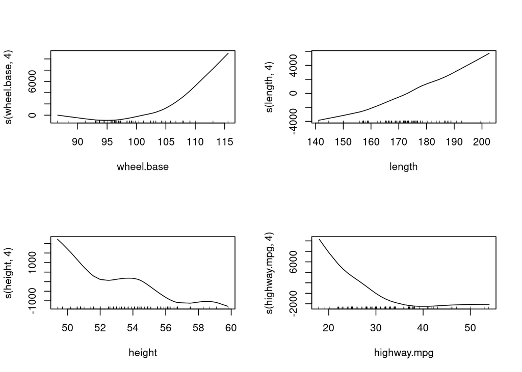

```r
plot(r.gam4)
```

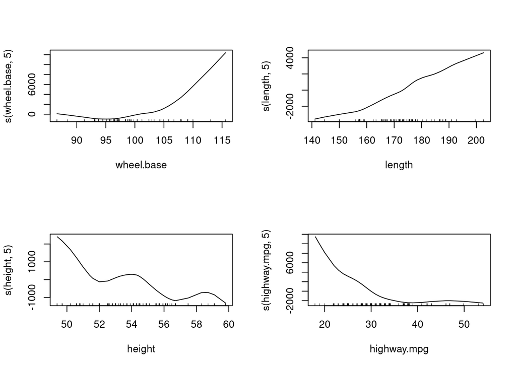

```r
plot(r.gam5)
```

## Cross-validation for Regression Splines

### 7, For cubic regression splines, let us consider using knots that are evenly distributed between the two extreme values (minimum and maximum) of the predictor variable, but excluding the two extreme values. That is, given the number of knots, m, we create the knots as follow:

```r
m = 5            # number of knots
(rg = range(auto$highway.mpg))# range of min and max of highway.mpg
```

```
## [1] 18 54
```

```r
(knots = seq(rg[1], rg[2], length=m+2)[-c(1,m+2)]) # create 5 knots excluding min / max values of highway.mpg
```

```
## [1] 24 30 36 42 48
```

### The following codes fit the cubic regression spline fit (with 5 knots) to the data (price vs. highway.mpg).A scatter plot of the two variables is shown.

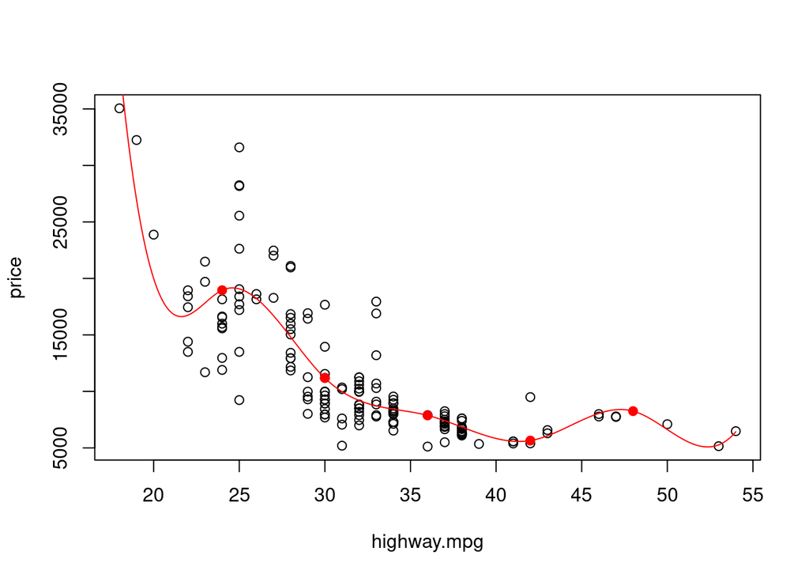

```r
## new dataframe is generated based on min / max value of highway.mpg
newx<- data.frame(highway.mpg = seq(min(auto$highway.mpg), max(auto$highway.mpg), by=0.1))

## cubic regression spline fitting with 5 knots
rcub = lm(price ~ bs(highway.mpg, knots=knots, degree=3), data=auto)
yhatcub = predict(rcub, newx)
## plotting, black points are data from auto; red curve shows fitted values based on test data newx; red dots shows 5 knots used for cubic spline fitting
with(auto, plot(highway.mpg, price))
lines(newx$highway.mpg, yhatcub, col="red")
points(knots, predict(rcub, data.frame(highway.mpg=knots)), col="red", pch=19)
```

### 8, Use 10-fold cross-validation to find an appropriate value for m. Consider m = 1, 2, …, 5 in your CV study. Explain why you have used the technique of same subsamples.

### The subsampling is defined in the second outer loop comparing to the knots searching in the inner loop; therefore for a generated new dataset of train and test, all knots of cubic spline fittings are done within the inner loop. The outer most loop is for the number of repetition for subsampling and knots searching process. The knots are chosen based on the min / max of each training set, but excluding end points. Prediction errors (PE) are calculated based on mse, and the minimum PE is found with four-knots cubic spline fittings.

```r
## cross validation / fitting m
R = 20                   # number of repetitions
m = 5                    # maximum knots we want to do spline regression
n = nrow(auto)           # data size
K = 10                   # K-fold CV
## function for shuffle the i-th sample from n size of data by K fold selection.
test.set = function(i, n, K=10) {
  if(i < 1 || i > K)
    stop(" i out of range (1, K)")
  start = round(1 + (i-1) * n / K)
  end = ifelse(i == K, n, round(i * n / K))
  start:end
}
##

set.seed(180)           # set a random seed
mse = matrix(nrow=R*K, ncol=m)
for(i in 1:R) {                  # for each repetition
  ind = sample(n)                # shuffle index
  for(k in 1:K) {                # for each fold
    index = ind[test.set(k, n, K)]
    test = auto[index,]
    train = auto[-index,]
    rgtrain = range(train$highway.mpg)
     # for each knots
    for(j in 1:m) {
      knots5 = seq(rgtrain[1], rgtrain[2], length=j+2)[-c(1,j+2)]
      rhw= lm(price ~ bs(highway.mpg, knots=knots5, degree=3, Boundary.knots = range(auto$highway.mpg)), data=train)
      yhathw = predict(rhw, test)        # prediction for test data
      mse[K*(i-1)+k,j] = mean( (test$price - yhathw)^2 )
    }
  }
}
mse
```

```
##            [,1]     [,2]      [,3]     [,4]        [,5]
##   [1,] 13750754 13305223  10932279  8250242   9563940.2
##   [2,]  5003731  5070613   4320867  5271937   6012239.7
##   [3,]  5296729  5115554   5096766  5745323   5650969.3
##   [4,] 18700279 19985574  15392922 10931139  18848139.0
##   [5,]  9979745  9829357   9500618 10089646  10523703.0
##   [6,]  5559532  5340709   4358719  4326376   5815132.8
##   [7,]  9484844  9180117  10745650 12985594  10492436.4
##   [8,] 19112001 20341535  20761097 17805172  15998598.3
##   [9,] 23975995 25736026  26175845 22290073  18811360.4
##  [10,] 14034519 15091535  12826697 10084026   7151049.3
##  [11,] 32004189 31259761  28136560 27085767  32769096.4
##  [12,]  3972780  4207331   5292100  5346281   5012922.4
##  [13,]  5001667  4864024   5040059  5294199   5042388.0
##  [14,] 15495223 15109220  13088846 12656571  14746951.1
```

[output cut: 186 more lines]

```r
## Prediction error PE for the different knots fitting
PE2<- cbind(knots = 1:ncol(mse), mse = colMeans(mse))
PE2
```

```
##      knots      mse
## [1,]     1 12530675
## [2,]     2 12815116
## [3,]     3 14074012
## [4,]     4 11332143
## [5,]     5 16429562
```

```r
## min PE - the best model has 4 knots, which gives minimum of prediction error.
PE2[which.min(PE2[,2])]
```

```
## [1] 4
```

### 9, Find your final model and show it in a scatter plot of the two variables.

### Best fitting is found with 4 knots, therefore underlying graph shows data with 4 knots fitted cubic spline curve.

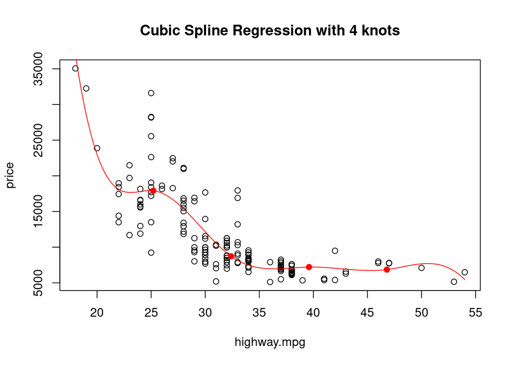

```r
rg = range(auto$highway.mpg)
knots4 = seq(rg[1], rg[2], length= 6)[-c(1,6)]
rhw4 = lm(price ~ bs(highway.mpg, knots = knots4, degree=3), data = auto)
yhathw4 = predict(rhw4, newx)
with(auto, plot(highway.mpg, price, main = "Cubic Spline Regression with 4 knots"))
lines(newx$highway.mpg, yhathw4, col="red")
points(knots4, predict(rhw4, data.frame(highway.mpg = knots4)), col="red", pch=19)
```

# Jackknifing and Parallel Computing

### 10, Use the Jackknifing technique (with a 90% for training and 10% for testing) to find an appropriate degree for polynomial regression as in Tasks 1-3. Use R = 200 as the number of repetitions.

### results shows the third degree polynomial fitting gives the minimun PE value, thus the best fitting.

Show the curve of the selected model in a scatter plot of the data.

```r
newx<- data.frame(highway.mpg = seq(min(auto$highway.mpg), max(auto$highway.mpg), by=0.1))
set.seed(189)
R = 200 # shuffle times
n = nrow(auto) # sample size
k = round(n*0.1) # test size (10% of sample size)
p = 5 # degrees of polynomial regression

mse = matrix(nrow=R, ncol=p)  # mse size (repetition no * degrees of polynomial)
for(j in 1:R) {
  index = sample(n, k)
  test = auto[index,]
  train = auto[-index,]
  for(i in 1:p) {
  r.poly<- lm(price ~ poly(highway.mpg,degree = i,raw = TRUE),data=train)
  pred.poly = predict(r.poly, test)
  mse[j,i] = mean((test$price - pred.poly)^2 )
  }
}
## MSE
mse
```

```
##            [,1]     [,2]     [,3]     [,4]     [,5]
##   [1,]  4695952  5939801  6243518  6395197  5754659
##   [2,]  8951108  4314566  3892691  3830153  4809189
##   [3,] 24791254 14427535 13703810 19248169 16392869
##   [4,] 12632353 15640450 16049716 16475012 15215512
##   [5,] 32604228 21980064 21547327 21497850 25954524
##   [6,] 13097838 11047079 11086457 10985037 10270768
##   [7,] 10744979  6625246  6574272  6404616  6557046
##   [8,] 27324853 14415477 13965111 19126372 15797783
##   [9,] 30458199 11297261 12763173 41112310 63038049
##  [10,] 10937341  8312322  9236103  9283986  8560293
##  [11,]  9590528  5134226  5395387  5192295  5299523
##  [12,] 31461313 24468793 25068810 25082559 26332272
##  [13,]  6412670  8361705  8824631  9044904  7897389
##  [14,] 11098350 12205299 13581219 13396729 12618657
```

[output cut: 186 more lines]

```r
## PEs for 1 - 5 degrees
PE3<- cbind(degree = 1:ncol(mse), mse = colMeans(mse))
PE3
```

```
##      degree      mse
## [1,]      1 17271743
## [2,]      2 11981374
## [3,]      3 11955641
## [4,]      4 12770674
## [5,]      5 12774749
```

```r
## Degree based on minimum PEs
PE3[which.min(colMeans(mse))]
```

```
## [1] 3
```

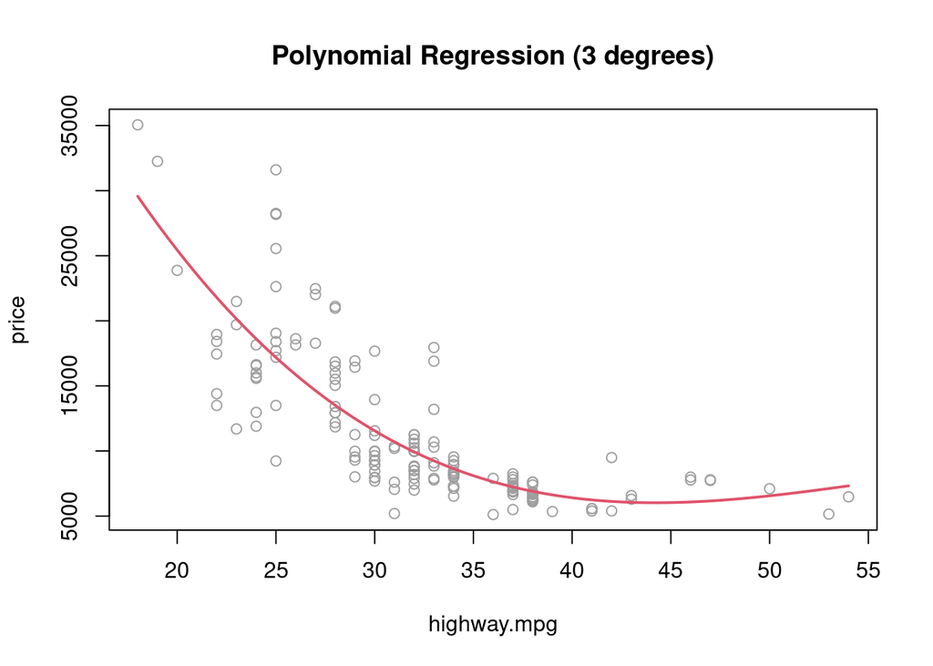

```r
## the 3rd degree polynomial regressions gives the minimum prediction error.
## Plotting based on 3rd degree polynomial regressions.
newx<- data.frame(highway.mpg = seq(min(auto$highway.mpg), max(auto$highway.mpg), by=0.1))
with(auto,plot(highway.mpg,price,pch=21,col=8, main="Polynomial Regression (3 degrees)"))
pred3 = predict(polyn3,newx)
lines(newx$highway.mpg,pred3,lwd = 2, col = 2)
```

### 11, Rewrite/reorganise your code so that each repetition can be carried out independently. Perform the Jackknifing selection of the polynomial degree using parallel computing. Compare the timings, when 1, 5, 10 or 20 cores are used.

```r
library(parallel)
## function for reshuffle of data, R shuffle times; K fold of sampling (10 means 10% test, 90% train); p degree of polynomial regressions
shuffle = function(R,K=10,p=5) {
   set.seed(189)
   k = round(n*(1/K))
   n = nrow(auto)
   index = sample(n, k)
   test = auto[index,]
   train = auto[-index,]
   for(i in 1:p) { ## calculate mse based on each train / test dataset
   r.poly<- lm(price ~ poly(highway.mpg,degree = i,raw = TRUE),data=train)
   pred.poly = predict(r.poly, test)
   mse[i] = mean((test$price - pred.poly)^2 )

  }
}


system.time({
    mclapply(1:200, function(R) shuffle(R ,K=10,p=5), mc.cores=1)
})
```

```
##    user  system elapsed
##   1.531   0.000   1.532
```

```r
## check results
colMeans(mse)
```

```
## [1] 17271743 11981374 11955641 12770674 12774749
```

```r
system.time({
    mclapply(1:200, function(R) shuffle(R ,K=10,p=5), mc.cores=5)
})
```

```
##    user  system elapsed
##   1.754   0.224   0.512
```

```r
system.time({
    mclapply(1:200, function(R) shuffle(R ,K=10,p=5), mc.cores=10)
})
```

```
##    user  system elapsed
##   0.585   0.204   0.275
```

```r
system.time({
    mclapply(1:200, function(R) shuffle(R ,K=10,p=5), mc.cores=20)
})
```

```
##    user  system elapsed
##   1.980   0.792   0.240
```

### 12, For results to be reproducible, it is better to use random seeds. Investigate and demonstrate how this can be achieved when mclapply() is used.

```r
system.time({
    mclapply(1:200, function(R) shuffle(R ,K=10,p=5),mc.set.seed = TRUE, mc.cores=5)
})
```

```
##    user  system elapsed
##   1.800   0.224   0.518
```

```r
## check results
colMeans(mse)
```

```
## [1] 17271743 11981374 11955641 12770674 12774749
```

# Summary